# econ412Week01_introduction slides

```python
from IPython.display import HTML
HTML('''<script>
  function code_toggle() {
    if (code_shown){
      $('div.input').hide('500');
      $('#toggleButton').val('Show Code')
    } else {
      $('div.input').show('500');
      $('#toggleButton').val('Hide Code')
    }
    code_shown = !code_shown
  }

  $( document ).ready(function(){
    code_shown=false;
    $('div.input').hide()
  });
</script>
<form action="javascript:code_toggle()"><input type="submit" id="toggleButton" value="Show Code"></form>''')
```

[figure not shown]

### ECON 412 International Economics: Trade

### Trimester 2, 2018

### Lecture Week 1: Introduction

#### 17 July 2018

### 1. Some Facts of Trade Patterns

- Remarkable growth of world trade since WW II. The ratio of trade (exports+imports) to GDP has increased.
  - [World trade as a share of world GDP](https://ourworldindata.org/international-trade).

[figure not shown]

- Trade in manufactured goods and services has been growing at a particularly fast pace.
  - Merchandise exports were 16.0 trillion USD in 2016.
  - Exports of services amounted to 4.0 trillion USD in 2016.
- Leading traded products are computers, motor cars, petroleum, clothing, ...
- Large exporters/importers are China, US, Germany, Japan, and UK.
  - They accounted for more than 1/3 of world trade in 2015.
- Top ten merchandise trading countries accounted for 52% of world total trade in 2015.
  - This share for service trade is 53% in 2015.
- Exports to GDP ratios differ across countries:
  - 24% for low-income countries, 37% for middle-income countries, and 42% for high-income countries.
- About half of the world trade is among the advanced economies.
- The share of intra-inudstry trade is large (over 60% of total trade).
- Only a small fraction of firms export.
- Fragmentation of production has been a major factor in the growth of trade and FDI.
  - About 1/3 of world trade is intra-firm (Helpman 2016).
  - Global production: Boeing 787 Dreamliner (Antras 2015)

[figure not shown]

### 2. Why do we study international trade

- Why do countries trade with each other?
- How do exports and imports trade affect national income?
- Which trade policies are good, for whom?
- How are trade policies determined?
- what explain that some firms participate in international trade but others do not?
- Why and how are production processes fragmented across countries?
- How does foregin trade affect income of various groups (inequality)?

### 3. Motivating examples

#### 3-1. NAFTA (North America Free Trade Agreement)

- NAFTA: What do politicians say?

```python
startTime=int(timedelta(hours=0, minutes=1, seconds=48).total_seconds())
stopTime=int(timedelta(hours=0, minutes=2, seconds=58).total_seconds())
#HTML('<iframe src="ClintonNAFTA.webm" width="700" height="394" frameborder="0" autoplay="0" webkitallowfullscreen mozallowfullscreen allowfullscreen></iframe>')
#HTML('<iframe width="700" height="394" src="https://www.youtube.com/embed/b3ooMrgXido?rel=0&amp;controls=0&amp;showinfo="1" frameborder="0" allowfullscreen></iframe>')
vid = YouTubeVideo("b3ooMrgXido", width=600, height=400, start=startTime, end=stopTime)
display(vid)
```

[video not shown]

```python
startTime=int(timedelta(hours=0, minutes=0, seconds=1).total_seconds())
stopTime=int(timedelta(hours=0, minutes=1, seconds=30).total_seconds())
#HTML('<iframe src="TrumpNAFTA.mp4" width="700" height="394" frameborder="0" autoplay="0" webkitallowfullscreen mozallowfullscreen allowfullscreen></iframe>')
#https://www.youtube.com/watch?v=8d8NaIwgL-4
#https://www.youtube.com/watch?v=F1sIZFU8cqs
vid2 = YouTubeVideo("F1sIZFU8cqs", width=600, height=400, start=startTime)
display(vid2)
```

[video not shown]

- NAFTA: What d trade studies find?
  - [Caliendo and Parro (2014)](https://doi.org/10.1093/restud/rdu035)

> We build into a Ricardian model sectoral linkages, trade in intermediate goods, and sectoral heterogeneity in production to quantify the trade and welfare effects from tariff changes. ... We apply our model and use our estimated elasticities to identify the impact of NAFTA's tariff reductions. We find that Mexico's welfare increases by 1.31%, U.S.'s welfare increases by 0.08%, and Canada's welfare declines by 0.06%. ...

#### 3-2. International trade and Inequality

- In the United States, earnings inequality has been rising (Autor 2014 Figure 1)
  - Reflected partly in rising college wage premium.
- Unskilled workers experience much slower growth in real wages (Autor 2014 Figure 6)

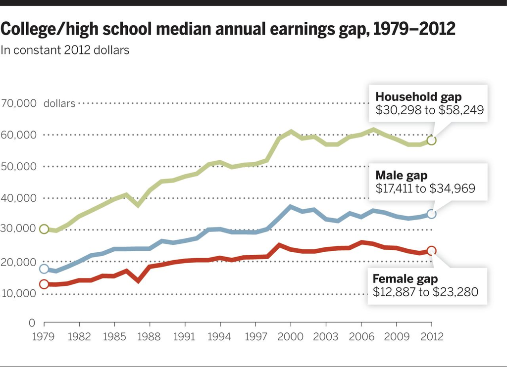

```python
autor2014Fig1 = Image(filename='autor2014ScienceFig1.jpg',width=680, height=360)
display(autor2014Fig1)
```

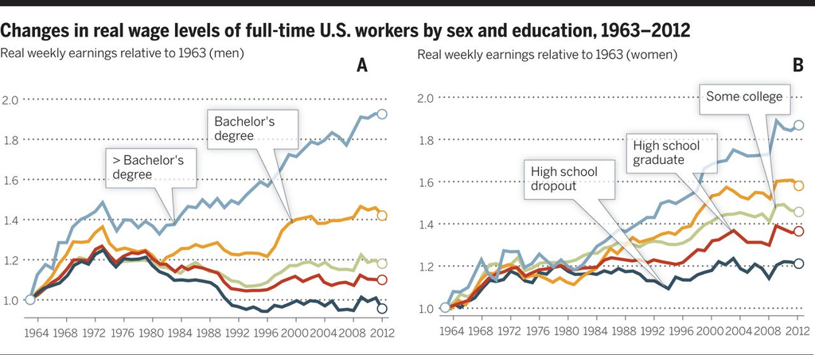

```python
autor2014Fig1 = Image(filename='autor2014ScienceFig6.jpg',width=700, height=420)
display(autor2014Fig1)
```

- Further, in 2000s, wage stagnated for most male workers, not for female workers.
- **To what extent is the earnings inequality attributed to international trade?**
  - Helpman (2016) concludes:

    > Trade can explain only a fraction, 20-25 percent, of the rise in the college wage premium.
  - College wage premium is mainly explained by **skill-biased technological change.**

#### 3-3. International trade and the local labor market

```python
LFPseries={}
# BLS data
#LFPseries['LFPrateAll'] = fred.get_series('CIVPART')
#LFPseries['LFTrate25_54']=fred.get_series('LNS11300060')
#LFPseries['LFTrateFemale']=fred.get_series('LNS11300002')
#LFPseries['LFTrateMale']=fred.get_series('LNS11300001')
# choose to use oecd data
LFPseries['LFTrateMale25_54']=fred.get_series('LRAC25MAUSM156N')
LFPseries['LFTrateFemale25_54']=fred.get_series('LRAC25FEUSM156S')
laborforces = pd.DataFrame(LFPseries)
fig, ax1 = plt.subplots(nrows=1, ncols=1, figsize=(8, 4), sharey='all')
ax1.plot(laborforces['LFTrateMale25_54'],  linewidth=1.2, label="Male")
ax1.plot(laborforces['LFTrateFemale25_54'], '--', linewidth=1.2, label="Female")
plt.autoscale(enable=True, axis='x', tight=True)
#ax1.set_xlim(loggdpCycle['qyC'].index[0],loggdpCycle['qyC'].index[-1])
ax1.set_title('Labor force participation rate, age 25-54')
ax1.legend(loc='lower right')
ax1.set_ylabel('Percent')
fig.tight_layout()
plt.show()
```

[output not shown]

[output not shown]

- **Did importing from China hurt the labor market in the U.S.?**
- Do politicians have a legitimate point?

```python
# Donald Trump on trade with China
# Youtube
#https://www.youtube.com/watch?v=bFZPNNn6wrk
startTime=int(timedelta(hours=0, minutes=0, seconds=20).total_seconds())
stopTime=int(timedelta(hours=0, minutes=1, seconds=0).total_seconds())
YouTubeVideo('bFZPNNn6wrk', width=600, height=400, start=startTime, end=stopTime)
```

[output not shown]

- How should we think about the declining labor force participation and trade?
  - Between 1999 and 2011, the U.S. lost close to 6 million manufacturing jobs (not a big number, relative to the total number of jobs)
  - Acemoglu, Autor, Dorn, Hanson and Price (2016, JOLE)

    > Job losses (in total economy) from rising Chinese import competition over 1999–2011 are in the range of 2.0–2.4 million.

### 4. What do we study?

- Theories explaining the patterns of international trade.
- Quantification of gains from international trade.
- Optimal policy on international trade.
- Firm heterogeneity in international trade, (if time permits).

#### Course overview

- Advanced International Trade: Theory and Evidence
  - Neoclassical trade theory: Ricardian model; Heckscher-Onlin model.
  - New trade theory: Increasing returns to scale, monopolistic competition.
  - Gravity equation, explaining trade flows.
  - Gains from trade.
  - Trade policy and the political economy of trade policy.
  - Trade and Firm heterogeneity.
    - Global value chains: offshoring (other names: outsourcing, fragmentation).

### Prerequisites?

- Microeconomic theory: producer theory; consumer theory; general equilibrium.
- Econometric methods: linear models; discrete choice; MLE; GMM; sample selection; endogeneity.
- (Undergraduate trade theory).

### Software

- The past 15 plus years was a golden time for the International Trade field.
  - Importantly, because of remarkable data availability at all levels.
- In addition to theory, you should learn to use software and empirical techniques for data analysis and estimation.
- Commonly used in economics: Stata, R, Python, Matlab, Fortran, C.
- And many more choices: SAS, SPSS, Gauss, Java, Perl, Julia, etc.

```python
stata= Image(filename='stata_logo_blue.jpg',width=100, height=80)
pylogo = Image(filename="python-logo-master-v3-TM.png",width=160, height=120)
Matlablogo = Image(filename="matlab_logo.png",width=160, height=120)
Rlogo = Image(filename="Rlogo.png",width=160, height=120)
#Image("python-logo-master-v3-TM.png")
#Rlogo = SVG(filename="Rlogo.svg",width=40, height=30)
#display(stata, Rlogo, Matlablogo, pylogo)
display(HTML("<table><tr><td><img src='stata_logo_blue.jpg', width=100, height=80></td><td><img src='Rlogo.png' width=100, height=80></td><td><img src='python-logo-master-v3-TM.png' width=140, height=120></td><td><img src='matlab_logo.png' width=140, height=130></td></tr></table>"))
#HTML('<iframe src=http://en.mobile.wikipedia.org/?useformat=mobile width=700 height=350></iframe>')
```